# ETC5521 Presentation Instructions

Take a fabulous plot and mess it up

Di Cook & Emi Tanaka

2020-10-19

The presentation is designed to develop your skills in understanding what makes an exploratory graphic better, by making a good plot worse! This involves elements like assessing what is effective, what would make it ineffective.

Most of the time you are asked to improve things, and this is really important. But it puts pressure on us always to be good and getting better. It can be cathartic to destroy something. You see this model in many video games, and even physical places you can go to smash things at [The Break Room](https://thebreakroom.com.au) in Melbourne, which advertises as “BREAK THINGS. FEEL GOOD.” So the goal is for this to be a fun exercise, but also a learning exercise because to make a plot worse you first need to work out what is done well.

The presentation represents 20% of your final grade for ETC5521.

1. You choose your presentation buddy, or two buddies. (Group can be 2 or 3.) Enter your **Monash username** in the row of your team [here](https://docs.google.com/spreadsheets/d/14WMGxOzlA6tYDfuQXoqDJmmlDSImzPZ3321YmsuonSM/edit?usp=sharing). You will have some time in your week 10 tutorial to form your teams. If you have problems one of the instructors or tutors can help out.
2. Your group will be assigned a plot from the Tidy Tuesday reports that was done really well. Your job will be to deconstruct it and make it worse! It is ok for your team to make more than one, but no more than three bad plots, in your solution. The plot that you will be assigned is one of the plots [here](https://raw.githubusercontent.com/numbats/eda/master/data/good-plots.zip). The plots will be randomly assigned to teams on Tue 20th October. You can find the code for the plot in the github repository from assignment 1 & 2. E.g. if your plot is `billby-figure-3.1.png` then go to `assignment-1-billby` repo and look for the code for Figure 3.1.
3. Your presentation will be 5 minutes long with 3 minutes of question time and each of your team members will need to present. The presentation will take place 4PM-7.30PM on 2nd Nov. Please note that there is some small chance that some presentations will need be held after 7.30PM. The presentation will be evaluated by the instructors and the tutors.

Resources: [Take a sad plot and make it better](https://alison.rbind.io/talk/2018-ohsu-sad-plot-better/)

Deadlines:

| Due date | Turn in | Points |
| --- | --- | --- |
| Step 1: 26th Oct | We will check that this has been done on the google sheet | 2 |
| Step 2: during class Nov 2 | Present during class | 18 |

## Marking guide for presentation

To help you with your presentation, below is a rubric to guide you to what we are expecting in your presentation:

| Content | Excellent (HD) | Very good (D) | Good (C) | Satisfactory (P) | Unsatisfactory (F) |
| --- | --- | --- | --- | --- | --- |
| Information, analysis and interpretation (35%) | The information and analysis are detailed, accurate and relevant to the presentation. Key points are made clear. | The information and analysis are detailed, accurate and relevant to the presentation. | The information and analysis are generally accurate and relevant, but some gaps or irrelvant materials. | The information and analysis is limited but generally relevant materials. | The presentaton and/or answers demonstrates limited knowledge, significant gaps and/or errors. |
| Structure (20%) | The presentation is well structured, logical and easy to follow. | The presentation is generally well structured and logical. | The presentation has a coherent flow. | The presentation conveys some flow but mostly disorganised. | The structure was unclear and incoherent. |
| Presentation Skills (20%) | The presentation is clear, lively and imaginative. The presentation makes good use of visual aids. | The presentation is generally clear and lively with appropriate use of visual aids. | The presentation conveys meaning but sometimes unclear or clumsy. | The presentation is not always clear or unengaging. | The presentation is quite clumsy or very dull. |
| Responses to question (15%) | The response to the question demonstrates mastery of knowledge and answers the question clearly. | The response to the question demonstrates knowledge and answers the question. | The response to the question demonstrates slight lack of knowledge but generally well answered. | The response to the question is satisfactory. | The response to the question demonstrates lack of knowledge or significant gaps or errors. |
| Time Management (10%) | Well timed. | More or less to time. | More or less to time but materials slightly rushed to fit within time. | More or less to time but materials rushed to fit within time. | Presentation is significantly under or over time. |

## Example

From team **goanna** was this amazing plot of temperature differences over time:

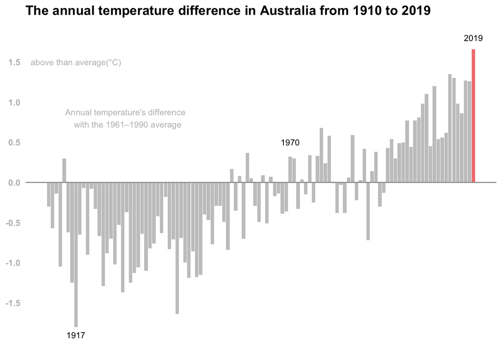

The plot for the difference between the average temperature of 1961-1990 (as baseline) and the annual average temperature for each year from 1910 to 2019, calculated by daily maximum temperature

Ways to make this bad

- remove the difference from the mean
- change to a line plot
- colour by year
- remove annotations
- add a smoother
- adding theme that puts the focus on the background and frame colours rather than the data elements
- using an image as a background
- adding irrelevant text

Here’s an example of a much poorer plot.

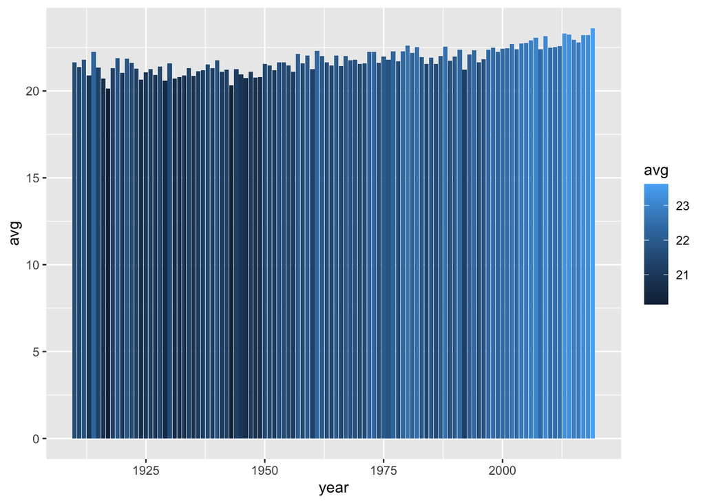